# sealey-briana-ADA-homework-4

Briana Sealey

5/10/2020

```r
#load packages
library(tidyverse)
library(patchwork)
library(devtools)
library(scales)
library(collapse)
library(BBmisc)
library(tidycovid19)
library(ggthemes)
library(AICcmodavg)
library(lme4)
theme_set(theme_tufte())
```

```r
#Setup for challenges
merged <- download_merged_data(cached = TRUE)
merged <- merged %>%
  group_by(country, iso3c) %>%
  arrange(country, iso3c, date) %>%
  ## new code to replace NAs with zeros
  mutate(
    confirmed = ifelse(is.na(confirmed), 0, confirmed),
    deaths = ifelse(is.na(deaths), 0, deaths),
    recovered = ifelse(is.na(recovered), 0, recovered)
  ) %>%
  ## end of new code
  mutate(
    daily_confirmed = confirmed - lag(confirmed, n = 1),
    daily_deaths = deaths - lag(deaths, n = 1),
    daily_recovered = recovered - lag(recovered, n = 1)
  ) %>%
  mutate(
    daily_confirmed = replace_na(daily_confirmed, 0),
    daily_deaths = replace_na(daily_deaths, 0),
    daily_recovered = replace_na(daily_recovered, 0)
  ) %>%
  ungroup() %>%
  arrange(country, iso3c, date)

add_world1 <- merged %>%
  group_by(date) %>%
  arrange(date) %>%
  summarize(
    country = "World", iso3c = NA,
    confirmed = sum(confirmed, na.rm = TRUE),
    deaths = sum(deaths, na.rm = TRUE),
    recovered = sum(recovered, na.rm = TRUE),
    timestamp = fmode(timestamp)
  ) %>%
  mutate(
    daily_confirmed = confirmed - lag(confirmed, n = 1),
    daily_deaths = deaths - lag(deaths, n = 1),
    daily_recovered = recovered - lag(recovered, n = 1)
  ) %>%
  mutate(
    daily_confirmed = replace_na(daily_confirmed, 0),
    daily_deaths = replace_na(daily_deaths, 0),
    daily_recovered = replace_na(daily_recovered, 0)
  ) %>%
  ungroup() %>%
  arrange(country, iso3c, date)

add_world2 <- merged %>%
  group_by(country, iso3c) %>%
  summarize(
    population = fmode(population),
    land_area_skm = fmode(land_area_skm),
    timestamp = fmode(timestamp)
  ) %>%
  ungroup() %>%
  summarize(
    country = "World", iso3c = NA,
    population = sum(population, na.rm = TRUE),
    land_area_skm = sum(land_area_skm, na.rm = TRUE)
  ) %>%
  mutate(pop_density = population / land_area_skm)

add_world <- left_join(add_world1, add_world2, by = c("country", "iso3c"))
merged <- bind_rows(merged, add_world)

cv_data <- pivot_longer(merged,
  cols = c(
    "confirmed", "deaths", "recovered",
    "daily_confirmed", "daily_deaths", "daily_recovered"
  ),
  names_to = "variable", values_to = "cases"
) %>%
  arrange(country, variable, date) %>%
  rename(area = land_area_skm, density = pop_density) %>%
  mutate(rate = cases / population * 10^6) %>%
  ## new code to omit data before 2020-05-11
  filter(date < "2020-05-11")
## end of new code

#Running function
cv_summary <- function(d, country_list = "World",
                       plot = TRUE, facet = "country",
                       status = c("confirmed", "deaths", "recovered")) {

  # based on `wes_palettes()` GrandBudapest1, IsleofDogs1, IsleofDogs2
  # from the {wesanderson} package
  my_palette <- c(
    "#5B1A18", "#FD6467", "#F1BB7B", "#D67236",
    "#0F0D0E", "#9986A5", "#79402E", "#CCBA72", "#D9D0D3", "#8D8680",
    "#EAD3BF", "#AA9486", "#B6854D", "#39312F", "#1C1718"
  )

  if (facet == "country") {
    fill <- "variable"
    n <- length(unique(d$variable)) / 2
    # need only half of unique # of variable (3)
  }

  if (facet == "variable") {
    fill <- "country"
    n <- length(country_list)
    # need number of countries
  }

  if ("All" %in% country_list) {
    country_list <- unique(d$country)
    country_list <- setdiff(country_list, "World")
  }

  if ("World" %in% country_list) {
    d <- d %>% filter(country %in% country_list)

    totals <- d %>%
      group_by(variable) %>%
      summarize(
        country = "World",
        cases = max(cases),
        population = max(population),
        area = max(area),
        density = max(density),
        rate = max(rate, na.rm = TRUE),
        on = max(date)
      ) %>%
      select(country, variable, cases, population, area, density, rate, on) %>%
      arrange(variable) %>%
      ungroup()
  }

  if ("World" %nin% country_list) {
    d <- d %>% filter(country %in% country_list)
    totals <- d %>%
      group_by(country, variable) %>%
      summarize(
        cases = max(cases),
        population = max(population),
        area = max(area),
        density = max(density),
        rate = max(rate, na.rm = TRUE),
        on = max(date),
        gdp_capita = fmode(gdp_capita),
        income = fmode(income),
        life_expectancy = fmode(life_expectancy),
        max_sd = max(soc_dist),
        max_mr = max(mov_rest)
      ) %>%
      select(
        country, variable, cases, population, area, density, rate,
        gdp_capita, income, life_expectancy, max_sd, max_mr, on
      ) %>%
      arrange(country, variable) %>%
      ungroup()
  }

  if (plot == TRUE) {
    cc <- filter(d, variable %in% status)
    cum_cases_plot <- ggplot(
      data = cc,
      # use the tidy evaluation pronoun .data to slice the chosen fill
      # variable from the data frame
      aes(
        x = date, y = cases + 1, color = .data[[fill]],
        fill = .data[[fill]]
      )
    ) +
      geom_point(size = 0.5) +
      geom_line() +
      # use the tidy evaluation pronoun .data to slice the chosen facet_wrap
      # variable from the data frame
      facet_wrap(~ .data[[facet]], ncol = 5) +
      xlab("Date") +
      ylab("Log Cumulative Cases") +
      scale_y_log10(
        breaks = trans_breaks("log10", function(x) 10^x),
        labels = trans_format("log10", math_format(10^.x))
      ) +
      scale_color_manual(
        aesthetics = c("color", "fill"),
        name = NULL, values = my_palette
      )

    dc <- filter(d, variable %in% paste0("daily_", status))
    daily_cases_plot <- ggplot(
      data = dc,
      aes(
        x = date, y = cases, color = .data[[fill]],
        fill = .data[[fill]]
      )
    ) +
      geom_point(size = 0.5) +
      geom_line() +
      facet_wrap(~ .data[[facet]], ncol = 5) +
      xlab("Date") +
      ylab("Daily Cases") +
      scale_color_manual(
        aesthetics = c("color", "fill"),
        name = NULL, values = my_palette
      )
  }

  if (plot == TRUE) {
    return(list(
      totals = totals,
      cum_cases_plot = cum_cases_plot,
      daily_cases_plot = daily_cases_plot
    ))
  } else {
    return(list(totals = totals))
  }
}
```

## CHALLENGE 1

```r
cv_summary(cv_data)
```

```
## $totals
## # A tibble: 6 x 8
##   country variable          cases population      area density   rate on
##   <chr>   <chr>             <dbl>      <dbl>     <dbl>   <dbl>  <dbl> <date>
## 1 World   confirmed       4100108 7523799801    1.27e8    59.4 545.   2020-05-10
## 2 World   daily_confirmed   99113 7523799801    1.27e8    59.4  13.2  2020-05-10
## 3 World   daily_deaths       8856 7523799801    1.27e8    59.4   1.18 2020-05-10
## 4 World   daily_recovered   65439 7523799801    1.27e8    59.4   8.70 2020-05-10
## 5 World   deaths           282666 7523799801    1.27e8    59.4  37.6  2020-05-10
## 6 World   recovered       1407676 7523799801    1.27e8    59.4 187.   2020-05-10
##
## $cum_cases_plot
```

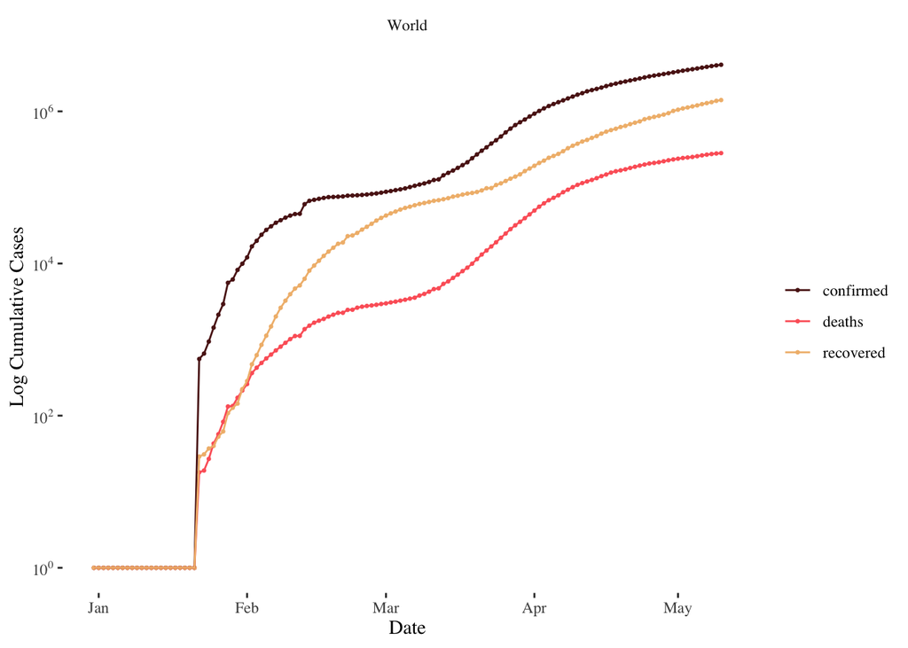

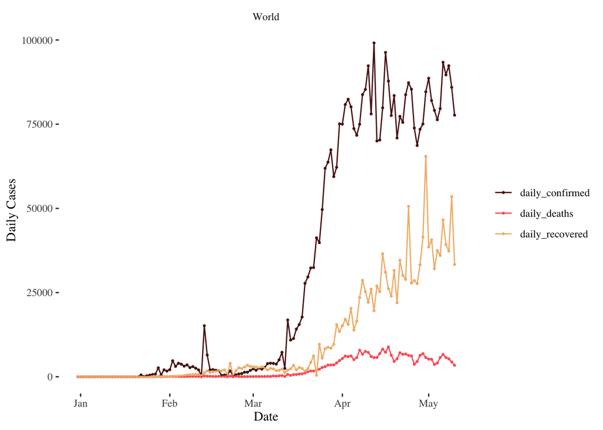

### CHALLENGE 2

```
## $totals
## # A tibble: 48 x 13
##    country variable cases population   area density    rate gdp_capita income
##    <chr>   <chr>    <dbl>      <dbl>  <dbl>   <dbl>   <dbl>      <dbl> <chr>
##  1 Canada  confirm… 70091   37057765 9.09e6    4.08 1.89e+3     51392. High …
##  2 Canada  daily_c…  2778   37057765 9.09e6    4.08 7.50e+1     51392. High …
##  3 Canada  daily_d…   251   37057765 9.09e6    4.08 6.77e+0     51392. High …
##  4 Canada  daily_r…  1385   37057765 9.09e6    4.08 3.74e+1     51392. High …
##  5 Canada  deaths    4991   37057765 9.09e6    4.08 1.35e+2     51392. High …
##  6 Canada  recover… 32109   37057765 9.09e6    4.08 8.66e+2     51392. High …
##  7 China   confirm… 84010 1392730000 9.39e6  148.   6.03e+1      7753. Upper…
##  8 China   daily_c… 15136 1392730000 9.39e6  148.   1.09e+1      7753. Upper…
##  9 China   daily_d…  1290 1392730000 9.39e6  148.   9.26e-1      7753. Upper…
## 10 China   daily_r…  3995 1392730000 9.39e6  148.   2.87e+0      7753. Upper…
## # … with 38 more rows, and 4 more variables: life_expectancy <dbl>,
## #   max_sd <dbl>, max_mr <dbl>, on <date>
##
## $cum_cases_plot
```

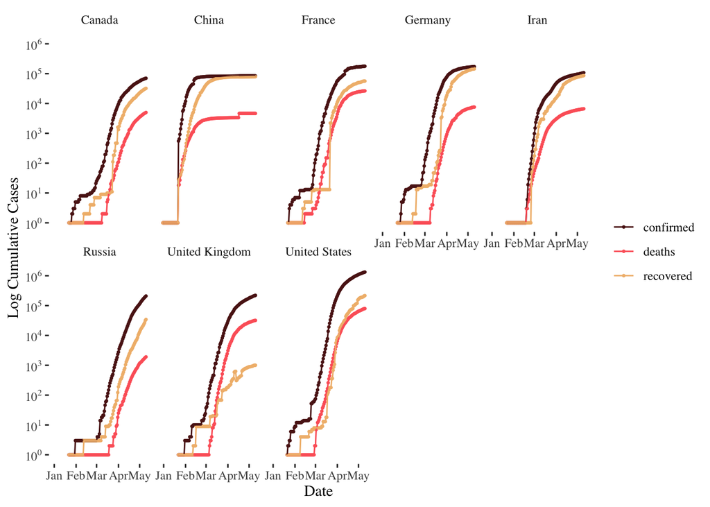

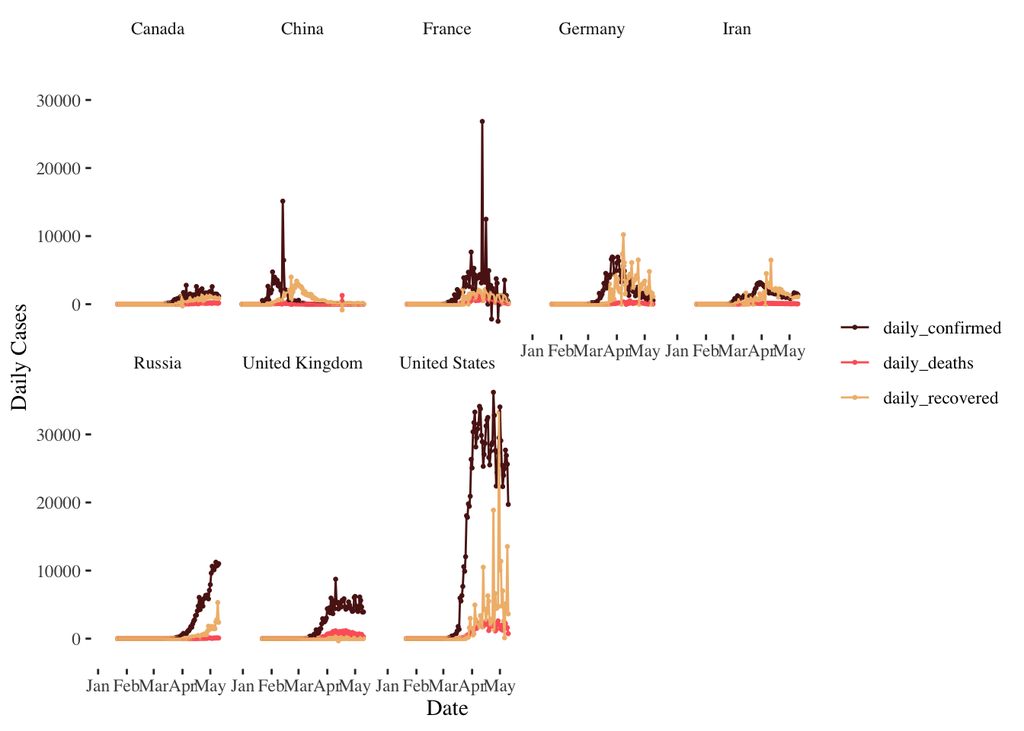

```r
#Figured out what the countries are named in the column using table
#table(cv_data$country)

#creating vector that includes on specified countries
G7 <- c("United States", "United Kingdom", "Canada", "France", "Germany", "China", "Russia", "Iran")

#Facet by country
cv_summary(cv_data, country_list = G7, facet = "country")
```

```r
#Facet by variable
cv_summary(cv_data, country_list = G7, facet = "variable")
```

```
## $totals
## # A tibble: 48 x 13
##    country variable cases population   area density    rate gdp_capita income
##    <chr>   <chr>    <dbl>      <dbl>  <dbl>   <dbl>   <dbl>      <dbl> <chr>
##  1 Canada  confirm… 70091   37057765 9.09e6    4.08 1.89e+3     51392. High …
##  2 Canada  daily_c…  2778   37057765 9.09e6    4.08 7.50e+1     51392. High …
##  3 Canada  daily_d…   251   37057765 9.09e6    4.08 6.77e+0     51392. High …
##  4 Canada  daily_r…  1385   37057765 9.09e6    4.08 3.74e+1     51392. High …
##  5 Canada  deaths    4991   37057765 9.09e6    4.08 1.35e+2     51392. High …
##  6 Canada  recover… 32109   37057765 9.09e6    4.08 8.66e+2     51392. High …
##  7 China   confirm… 84010 1392730000 9.39e6  148.   6.03e+1      7753. Upper…
##  8 China   daily_c… 15136 1392730000 9.39e6  148.   1.09e+1      7753. Upper…
##  9 China   daily_d…  1290 1392730000 9.39e6  148.   9.26e-1      7753. Upper…
## 10 China   daily_r…  3995 1392730000 9.39e6  148.   2.87e+0      7753. Upper…
## # … with 38 more rows, and 4 more variables: life_expectancy <dbl>,
## #   max_sd <dbl>, max_mr <dbl>, on <date>
##
## $cum_cases_plot
```

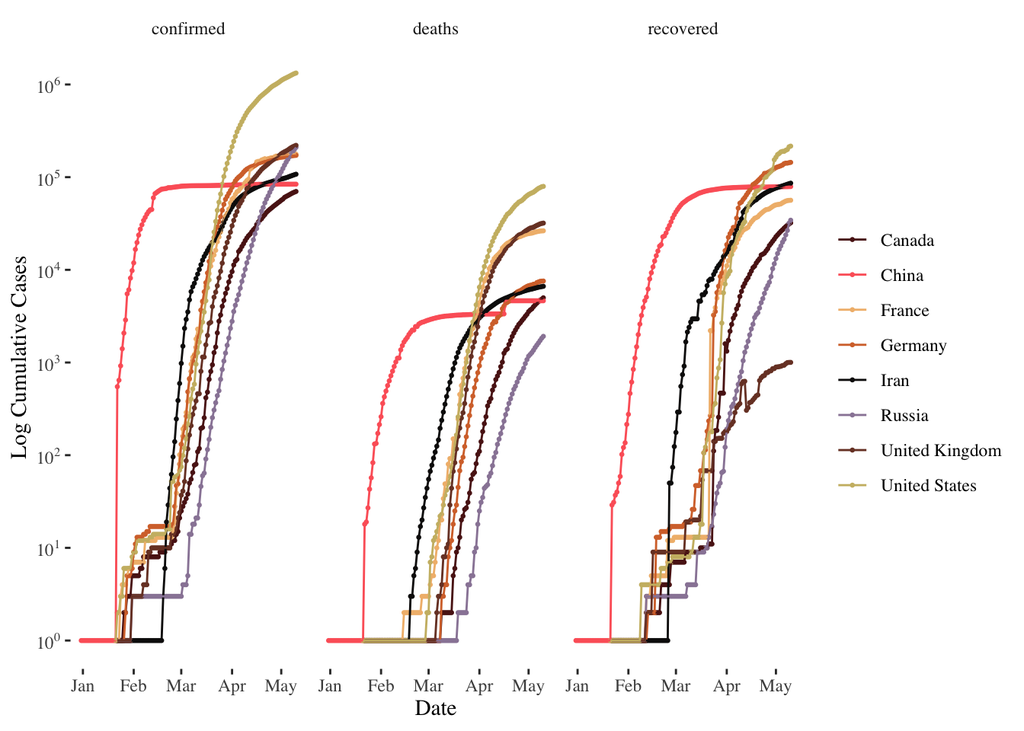

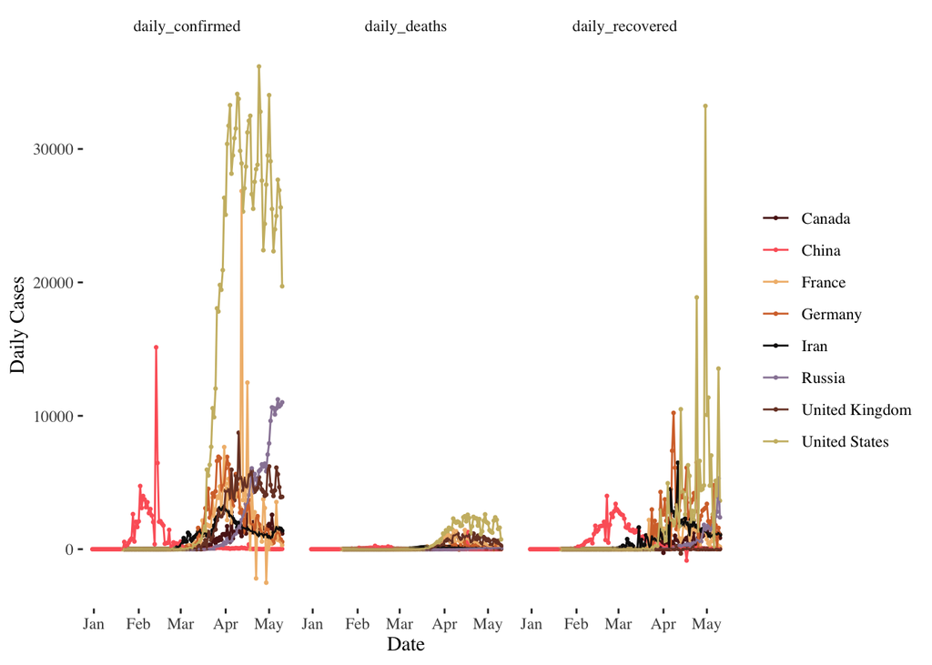

### CHALLENGE 3

```r
#datafrrame with all countries
all_summary <- cv_summary(cv_data, country_list = "All", plot = FALSE)
#turn the list into a dataframe
all_summary <- as.data.frame(all_summary$totals)

#Filter to create tibble d
all_summary %>%
  filter(population > 1000000) -> d
as_tibble(d)
```

```
## # A tibble: 924 x 13
##    country variable cases population   area density    rate gdp_capita income
##    <chr>   <chr>    <dbl>      <dbl>  <dbl>   <dbl>   <dbl>      <dbl> <chr>
##  1 Afghan… confirm…  4402   37172386 652860    56.9 118.          564. Low i…
##  2 Afghan… daily_c…   369   37172386 652860    56.9   9.93        564. Low i…
##  3 Afghan… daily_d…    13   37172386 652860    56.9   0.350       564. Low i…
##  4 Afghan… daily_r…    56   37172386 652860    56.9   1.51        564. Low i…
##  5 Afghan… deaths     120   37172386 652860    56.9   3.23        564. Low i…
##  6 Afghan… recover…   558   37172386 652860    56.9  15.0         564. Low i…
##  7 Albania confirm…   868    2866376  27400   105.  303.         5079. Upper…
##  8 Albania daily_c…    34    2866376  27400   105.   11.9        5079. Upper…
##  9 Albania daily_d…     4    2866376  27400   105.    1.40       5079. Upper…
## 10 Albania daily_r…    31    2866376  27400   105.   10.8        5079. Upper…
## # … with 914 more rows, and 4 more variables: life_expectancy <dbl>,
## #   max_sd <dbl>, max_mr <dbl>, on <date>
```

```r
head(d, 5)
```

```
##       country        variable cases population   area  density       rate
## 1 Afghanistan       confirmed  4402   37172386 652860 56.93776 118.421239
## 2 Afghanistan daily_confirmed   369   37172386 652860 56.93776   9.926724
## 3 Afghanistan    daily_deaths    13   37172386 652860 56.93776   0.349722
## 4 Afghanistan daily_recovered    56   37172386 652860 56.93776   1.506495
## 5 Afghanistan          deaths   120   37172386 652860 56.93776   3.228203
##   gdp_capita     income life_expectancy max_sd max_mr         on
## 1   563.8257 Low income          64.486      6      7 2020-05-10
## 2   563.8257 Low income          64.486      6      7 2020-05-10
## 3   563.8257 Low income          64.486      6      7 2020-05-10
## 4   563.8257 Low income          64.486      6      7 2020-05-10
## 5   563.8257 Low income          64.486      6      7 2020-05-10
```

### CHALLENGE 4

```r
d %>%
  filter(variable == "confirmed") -> overall
head(overall, 5)
```

```
##       country  variable cases population    area   density       rate
## 1 Afghanistan confirmed  4402   37172386  652860  56.93776 118.421239
## 2     Albania confirmed   868    2866376   27400 104.61226 302.821402
## 3     Algeria confirmed  5723   42228429 2381740  17.73008 135.524814
## 4      Angola confirmed    45   30809762 1246700  24.71305   1.460576
## 5   Argentina confirmed  6034   44494502 2736690  16.25851 135.612261
##   gdp_capita              income life_expectancy max_sd max_mr         on
## 1   563.8257          Low income          64.486      6      7 2020-05-10
## 2  5079.4011 Upper middle income          78.458      8     12 2020-05-10
## 3  4764.3756 Upper middle income          76.693      7     18 2020-05-10
## 4  3229.6197 Lower middle income          60.782      9     13 2020-05-10
## 5 10043.5086 Upper middle income          76.520      4      9 2020-05-10
```

```r
top_overall <- overall[order(-overall$rate), ]
#Top 10
head(top_overall, 10)
```

```
##            country  variable   cases population    area    density     rate
## 113          Qatar confirmed   22520    2781677   11610  239.59320 8095.836
## 128          Spain confirmed  224350   46796540  499564   93.52906 4794.158
## 65         Ireland confirmed   22996    4867309   68890   70.45298 4724.582
## 13         Belgium confirmed   53081   11433256   30280  377.21493 4642.684
## 121      Singapore confirmed   23336    5638676     709 7952.99842 4138.560
## 147  United States confirmed 1329260  326687501 9147420   35.76609 4068.904
## 67           Italy confirmed  219070   60421760  294140  205.45075 3625.681
## 133    Switzerland confirmed   30305    8513227   39516  215.52138 3559.755
## 146 United Kingdom confirmed  220449   66460344  241930  274.82739 3317.001
## 10         Bahrain confirmed    4941    1569439     778 2017.27370 3148.259
##     gdp_capita      income life_expectancy max_sd max_mr         on
## 113   63260.56 High income        80.10000      4      5 2020-05-10
## 128   32949.58 High income        83.33415      8      7 2020-05-10
## 65    76880.81 High income        82.60732     18      8 2020-05-10
## 13    47166.48 High income        81.59512      8      4 2020-05-10
## 121   58247.87 High income        83.14634     35     19 2020-05-10
## 147   54579.02 High income        78.53902      5     12 2020-05-10
## 67    35431.86 High income        82.94634     13     14 2020-05-10
## 133   79214.35 High income        83.55122     11     13 2020-05-10
## 146   43324.59 High income        81.35610     11      1 2020-05-10
## 10    21438.41 High income        77.16300      6      7 2020-05-10
```

```r
d %>%
  filter(variable == "daily_confirmed") -> daily
head(daily, 5)
```

```
##       country        variable cases population    area   density       rate
## 1 Afghanistan daily_confirmed   369   37172386  652860  56.93776  9.9267236
## 2     Albania daily_confirmed    34    2866376   27400 104.61226 11.8616678
## 3     Algeria daily_confirmed   199   42228429 2381740  17.73008  4.7124651
## 4      Angola daily_confirmed     7   30809762 1246700  24.71305  0.2272007
## 5   Argentina daily_confirmed   291   44494502 2736690  16.25851  6.5401339
##   gdp_capita              income life_expectancy max_sd max_mr         on
## 1   563.8257          Low income          64.486      6      7 2020-05-10
## 2  5079.4011 Upper middle income          78.458      8     12 2020-05-10
## 3  4764.3756 Upper middle income          76.693      7     18 2020-05-10
## 4  3229.6197 Lower middle income          60.782      9     13 2020-05-10
## 5 10043.5086 Upper middle income          76.520      4      9 2020-05-10
```

```r
top_daily <- daily[order(-daily$rate), ]
#Top 10
head(top_daily, 10)
```

```
##       country        variable cases population   area    density     rate
## 40    Ecuador daily_confirmed 11536   17084357 248360   68.78868 675.2376
## 113     Qatar daily_confirmed  1311    2781677  11610  239.59320 471.2984
## 48     France daily_confirmed 26849   66977107 547557  122.33840 400.8683
## 65    Ireland daily_confirmed  1515    4867309  68890   70.45298 311.2603
## 73     Kuwait daily_confirmed  1065    4137309  17820  232.17222 257.4137
## 121 Singapore daily_confirmed  1426    5638676    709 7952.99842 252.8962
## 13    Belgium daily_confirmed  2454   11433256  30280  377.21493 214.6370
## 10    Bahrain daily_confirmed   330    1569439    778 2017.27370 210.2662
## 128     Spain daily_confirmed  9630   46796540 499564   93.52906 205.7844
## 12    Belarus daily_confirmed  1485    9483499 202988   46.72880 156.5878
##     gdp_capita              income life_expectancy max_sd max_mr         on
## 40    5185.091 Upper middle income        76.80000      3     11 2020-05-10
## 113  63260.558         High income        80.10000      4      5 2020-05-10
## 48   43663.585         High income        82.52683      7      6 2020-05-10
## 65   76880.808         High income        82.60732     18      8 2020-05-10
## 73   33112.130         High income        75.39800     13      9 2020-05-10
## 121  58247.873         High income        83.14634     35     19 2020-05-10
## 13   47166.484         High income        81.59512      8      4 2020-05-10
## 10   21438.410         High income        77.16300      6      7 2020-05-10
## 128  32949.582         High income        83.33415      8      7 2020-05-10
## 12    6744.499 Upper middle income        74.17561      2      7 2020-05-10
```

**Top 10 Based on overall rate:** Qatar, Spain, Ireland, Belgium, Singapore, US, Italy, Switzerland, UK, Bahrain

**Top 10 Based on daily rate:** Ecuador, Qatar, France, Ireland, Kuwait, Singapore, Belgium, Bahrain, Spain, Belarus

### CHALLENGE 5

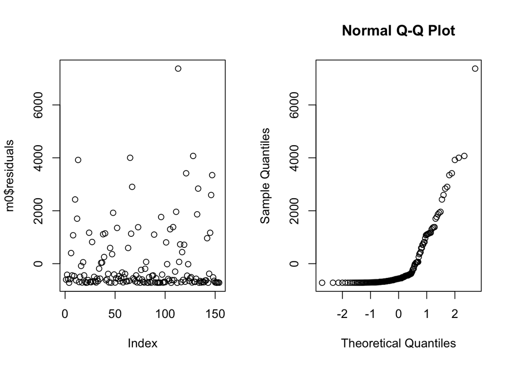

```r
m0 <- lm(data = overall, rate ~ 1)
#Set up plot window
par(mfrow=c(1,2))
plot(m0$residuals) #not normal
qqnorm(m0$residuals) #not normal
```

```r
shapiro.test(m0$residuals) #not normal
```

```
##
##  Shapiro-Wilk normality test
##
## data:  m0$residuals
## W = 0.62958, p-value < 2.2e-16
```

```r
summary(m0)
```

```
##
## Call:
## lm(formula = rate ~ 1, data = overall)
##
## Residuals:
##    Min     1Q Median     3Q    Max
## -722.0 -690.9 -565.0   63.4 7373.8
##
## Coefficients:
##             Estimate Std. Error t value Pr(>|t|)
## (Intercept)   722.04      99.67   7.244 1.99e-11 ***
## ---
## Signif. codes:  0 '***' 0.001 '**' 0.01 '*' 0.05 '.' 0.1 ' ' 1
##
## Residual standard error: 1237 on 153 degrees of freedom
```

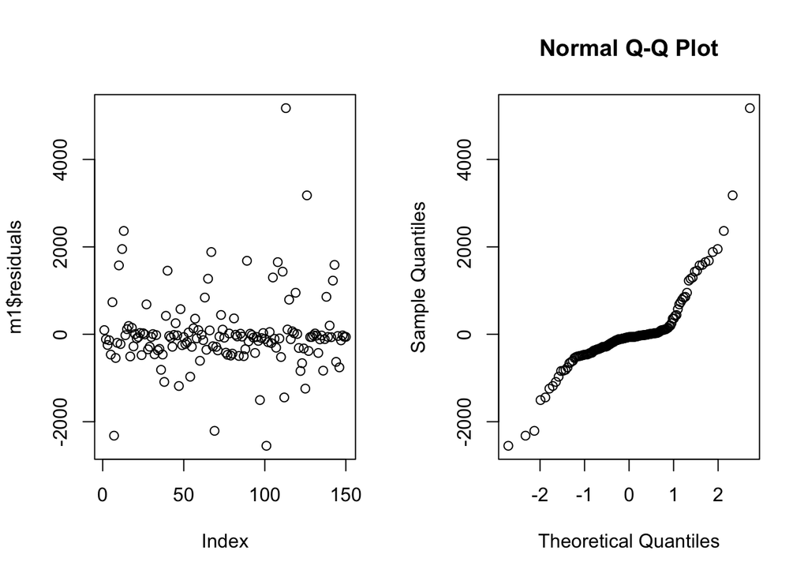

```r
m1 <- lm(data = overall, rate ~ density + population + gdp_capita + income)
plot(m1$residuals) #not normal
qqnorm(m1$residuals) #not normal
```

```r
shapiro.test(m1$residuals) #not normal
```

```
##
##  Shapiro-Wilk normality test
##
## data:  m1$residuals
## W = 0.78925, p-value = 2.029e-13
```

```r
summary(m1)
```

```
##
## Call:
## lm(formula = rate ~ density + population + gdp_capita + income,
##     data = overall)
##
## Residuals:
##     Min      1Q  Median      3Q     Max
## -2551.0  -331.0   -63.5    48.9  5174.3
##
## Coefficients:
##                             Estimate Std. Error t value Pr(>|t|)
## (Intercept)                2.198e+02  2.787e+02   0.789   0.4315
## density                    2.256e-01  1.087e-01   2.077   0.0396 *
## population                -9.580e-08  4.486e-07  -0.214   0.8312
## gdp_capita                 4.186e-02  6.668e-03   6.277 3.87e-09 ***
## incomeLow income          -2.304e+02  3.227e+02  -0.714   0.4764
## incomeLower middle income -2.202e+02  3.046e+02  -0.723   0.4709
## incomeUpper middle income -3.939e+01  2.725e+02  -0.145   0.8852
## ---
## Signif. codes:  0 '***' 0.001 '**' 0.01 '*' 0.05 '.' 0.1 ' ' 1
##
## Residual standard error: 878.1 on 143 degrees of freedom
##   (4 observations deleted due to missingness)
## Multiple R-squared:  0.5249, Adjusted R-squared:  0.505
## F-statistic: 26.33 on 6 and 143 DF,  p-value: < 2.2e-16
```

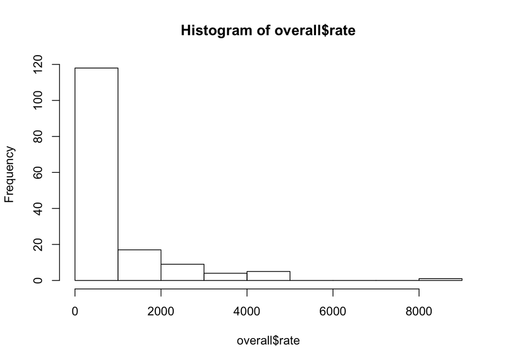

```r
#Density & gdp_capita are significant predictor variables, however this model is not normal

#Distribution of rate is skewed, needs to be transformed
#Turn plot window back to 1 plot per page
par(mfrow=c(1,1))
hist(overall$rate)
```

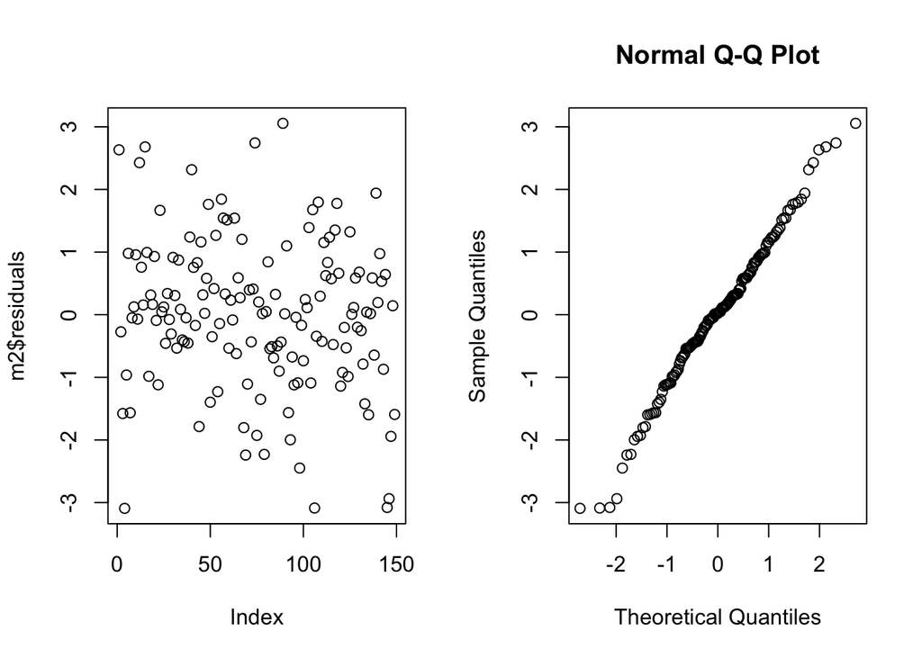

```r
overall2 <- overall
#Replace 0's with NA in the dataset
overall2[overall2 == 0] <- NA
#I checked to make sure NA's were removed
#overall2$gdp_capita
m2 <- lm(data = overall2, log(rate) ~ log(density) * log(population) * log(gdp_capita) * income)
par(mfrow=c(1,2))
plot(m2$residuals) #normal
qqnorm(m2$residuals) #normal
```

```r
shapiro.test(m2$residuals) #normal
```

```
##
##  Shapiro-Wilk normality test
##
## data:  m2$residuals
## W = 0.98971, p-value = 0.3462
```

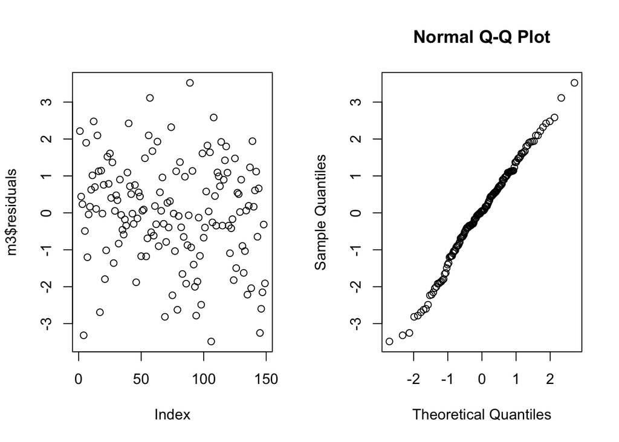

```r
#summary(m2) #not shown in html, very long because it includes all interactions
#After looking at summary, predictor variables are different from 0, but none of their estimates were significant

m3 <- lm(data = overall2, log(rate) ~ log(density) + log(population) + log(gdp_capita) + income)
par(mfrow=c(1,2))
plot(m3$residuals)
qqnorm(m3$residuals)
```

```r
shapiro.test(m3$residuals)
```

```
##
##  Shapiro-Wilk normality test
##
## data:  m3$residuals
## W = 0.99117, p-value = 0.4806
```

```r
summary(m3)
```

```
##
## Call:
## lm(formula = log(rate) ~ log(density) + log(population) + log(gdp_capita) +
##     income, data = overall2)
##
## Residuals:
##     Min      1Q  Median      3Q     Max
## -3.4827 -0.8328  0.0527  0.9589  3.5207
##
## Coefficients:
##                           Estimate Std. Error t value Pr(>|t|)
## (Intercept)               -3.55854    2.95087  -1.206 0.229850
## log(density)               0.22345    0.08930   2.502 0.013480 *
## log(population)           -0.05094    0.08427  -0.605 0.546465
## log(gdp_capita)            1.00409    0.26668   3.765 0.000243 ***
## incomeLow income          -0.25658    1.11256  -0.231 0.817941
## incomeLower middle income -0.69847    0.79670  -0.877 0.382125
## incomeUpper middle income -0.01889    0.51275  -0.037 0.970661
## ---
## Signif. codes:  0 '***' 0.001 '**' 0.01 '*' 0.05 '.' 0.1 ' ' 1
##
## Residual standard error: 1.406 on 142 degrees of freedom
##   (5 observations deleted due to missingness)
## Multiple R-squared:  0.6109, Adjusted R-squared:  0.5944
## F-statistic: 37.15 on 6 and 142 DF,  p-value: < 2.2e-16
```

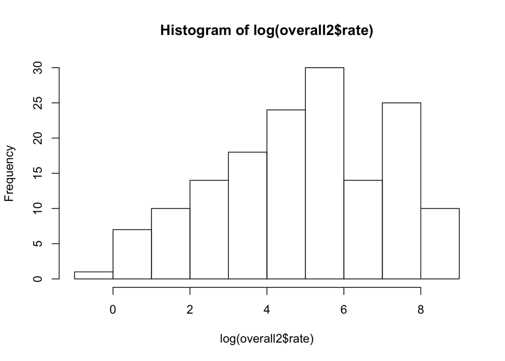

```r
#The histogram is at least a little better wrt to distribution
par(mfrow=c(1,1))
hist(log(overall2$rate))
```

Looks like `m3` best describes the data. Log-transformed density & log-transformed gdp_capita are significant predictor variables of log-transformed rate.

### CHALLENGE 6

```r
library(MASS)
step_full <- stepAIC(m3, scope = . ~ ., direction = "both")
```

```
## Start:  AIC=108.3
## log(rate) ~ log(density) + log(population) + log(gdp_capita) +
##     income
##
##                   Df Sum of Sq    RSS    AIC
## - income           3    7.6833 288.25 106.33
## - log(population)  1    0.7221 281.29 106.68
## <none>                         280.57 108.30
## - log(density)     1   12.3701 292.94 112.73
## - log(gdp_capita)  1   28.0117 308.58 120.48
##
## Step:  AIC=106.33
## log(rate) ~ log(density) + log(population) + log(gdp_capita)
##
##                   Df Sum of Sq    RSS    AIC
## - log(population)  1      1.52 289.77 105.11
## <none>                         288.26 106.33
## + income           3      7.68 280.57 108.30
## - log(density)     1     12.21 300.46 110.51
## - log(gdp_capita)  1    402.91 691.16 234.63
##
## Step:  AIC=105.11
## log(rate) ~ log(density) + log(gdp_capita)
##
##                   Df Sum of Sq    RSS    AIC
## <none>                         289.77 105.11
## + log(population)  1      1.52 288.26 106.33
## + income           3      8.48 281.29 106.68
## - log(density)     1     11.36 301.13 108.84
## - log(gdp_capita)  1    412.87 702.64 235.09
```

```r
detach(package:MASS)
```

Based on the stepwise AIC, a simpler model that includes only the **log-transformed density** and **log-transformed gdp_capita** are preferred. That is, these two parameters best explains the response variable. This is indicated by the Step AIC = 105.11, which is lower than the previous steps.

```r
library(MuMIn)
m3 <- lm(data = overall2, log(rate) ~ log(density) + log(population) + log(gdp_capita) + income)
m4 <- lm(data = overall2, log(rate) ~ log(density) + log(gdp_capita))
#creating AIC table
(aic_table <- aictab(list(m3, m4), modnames = c("m3", "m4")))
```

```
##
## Model selection based on AICc:
##
##    K   AICc Delta_AICc AICcWt Cum.Wt      LL
## m4 4 530.23       0.00   0.88   0.88 -260.98
## m3 8 534.17       3.94   0.12   1.00 -258.57
```

```r
r.squaredGLMM(m3)
```

```
##            R2m       R2c
## [1,] 0.6009867 0.6009867
```

```r
r.squaredGLMM(m4)
```

```
##            R2m       R2c
## [1,] 0.5948336 0.5948336
```

Lools like `m4` best explains the greatest amount of variance in the dataset as calculated by AIC’s. Furthermore, comparing the pseudo-$R^{2}$, `m3` is not significantly greater than `m4` (a 0.0061531 difference), thus the simpler model `m4` is still a better model for explaining the variance in the response variable.

### CHALLENGE 7

```r
#Adding in max_sd & max_mr
m5 <- lm(data = overall2, log(rate) ~ log(density) + log(gdp_capita) + max_sd)
m6 <- lm(data = overall2, log(rate) ~ log(density) + log(gdp_capita) + max_mr)
m7 <- lm(data = overall2, log(rate) ~ log(density) + log(gdp_capita) + max_sd + max_mr)

(aic_table <- aictab(list(m4, m5, m6, m7), modnames = c("m4", "m5", "m6", "m7")))
```

```
##
## Model selection based on AICc:
##
##    K   AICc Delta_AICc AICcWt Cum.Wt      LL
## m7 6 509.35       0.00   0.87   0.87 -248.37
## m5 5 513.14       3.79   0.13   1.00 -251.35
## m6 5 526.84      17.49   0.00   1.00 -258.21
## m4 4 530.23      20.88   0.00   1.00 -260.98
```

```r
r.squaredGLMM(m4)
```

```
##            R2m       R2c
## [1,] 0.5948336 0.5948336
```

```r
r.squaredGLMM(m5)
```

```
##           R2m      R2c
## [1,] 0.588734 0.588734
```

```r
r.squaredGLMM(m6)
```

```
##            R2m       R2c
## [1,] 0.5967799 0.5967799
```

```r
r.squaredGLMM(m7)
```

```
##            R2m       R2c
## [1,] 0.5921483 0.5921483
```

AIC calculation now deems `m7` as the best model and `m4` as the worst. However, the pseudo-$R^{2}$ values of `m5`, `m6` & `m4` are not significantly different than `m7`’s, thus the simpler `m4` is still sufficient enough in explaining the variance in log-transformed rate. This goes to show that relying purely on AIC values–or rather, one model selection test alone–is not enough to make a decision on which model is best; instead, more than one test should be done and compared before making a final decision.

### CHALLENGE 8

```r
#Filtering dataframe
d2 <- cv_data %>%
  filter(population > 1000000 & variable == "daily_confirmed" & rate > 0)

#I checked to make sure filter() worked
#d2$population
#d2$variable
#d2$rate

#Creating all models to be tested
#Null model with only random effects country + date
m0 <- lmer(data = d2, log(rate) ~ (1 | country) + (1 | date), REML = FALSE)

#Full model with density + gdp + soc + mov & random effects country + date
m1 <- lmer(data = d2, log(rate) ~ log(density) + log(gdp_capita) + soc_dist + mov_rest + (1 | country) + (1 | date), REML = FALSE)

#Nested model with density + gdp + soc & random effects country + date
m2 <- lmer(data = d2, log(rate) ~ log(density) + log(gdp_capita) + soc_dist + (1 | country) + (1 | date), REML = FALSE)
#Nested model with density + gdp + mov & random effects country + date
m3 <- lmer(data = d2, log(rate) ~ log(density) + log(gdp_capita) + mov_rest + (1 | country) + (1 | date), REML = FALSE)
#Nested model with density + soc + mov & random effects country + date
m4 <- lmer(data = d2, log(rate) ~ log(density) + soc_dist + mov_rest + (1 | country) + (1 | date), REML = FALSE)
#Nested model with density + gdp & random effects country + date
m5 <- lmer(data = d2, log(rate) ~ log(density) + log(gdp_capita) + (1 | country) + (1 | date), REML = FALSE)
#Nested model with density & random effects country + date
m6 <- lmer(data = d2, log(rate) ~ log(density) + (1 | country) + (1 | date), REML = FALSE)
#Nested model with gdp + soc + mov & random effects country + date
m7 <- lmer(data = d2, log(rate) ~ log(gdp_capita) + soc_dist + mov_rest + (1 | country) + (1 | date), REML = FALSE)
#Nested model with gdp + soc & random effects country + date
m8 <- lmer(data = d2, log(rate) ~ log(gdp_capita) + soc_dist + (1 | country) + (1 | date), REML = FALSE)
#Nested model with gdp + mov & random effects country + date
m9 <- lmer(data = d2, log(rate) ~ log(gdp_capita) + mov_rest + (1 | country) + (1 | date), REML = FALSE)
#Nested model with gdp & random effects country + date
m10 <- lmer(data = d2, log(rate) ~ log(gdp_capita) + (1 | country) + (1 | date), REML = FALSE)
#Nested model with soc + mov & random effects country + date
m11 <- lmer(data = d2, log(rate) ~ soc_dist + mov_rest + (1 | country) + (1 | date), REML = FALSE)

#AIC test
(aic_table <- aictab(list(m0, m1, m2, m3, m4, m5, m6, m7, m8, m9, m10, m11), modnames = c("m0","m1","m2","m3", "m4","m5", "m6", "m7", "m8", "m9", "m10", "m11")))
```

```
##
## Model selection based on AICc:
##
##     K     AICc Delta_AICc AICcWt Cum.Wt        LL
## m1  8 25469.13       0.00      1      1 -12726.56
## m2  7 25551.11      81.98      0      1 -12768.55
## m7  7 25665.08     195.95      0      1 -12825.53
## m8  6 25744.22     275.09      0      1 -12866.11
## m4  7 25754.13     285.00      0      1 -12870.06
## m3  7 25777.49     308.36      0      1 -12881.74
## m5  6 25847.77     378.64      0      1 -12917.88
## m11 6 25953.11     483.98      0      1 -12970.55
## m9  6 25985.09     515.95      0      1 -12986.54
## m10 5 26052.46     583.32      0      1 -13021.22
## m6  5 26426.13     957.00      0      1 -13208.06
## m0  4 26634.61    1165.47      0      1 -13313.30
```

```r
#Looks like m1 is best
summary(m1)
```

```
## Linear mixed model fit by maximum likelihood  ['lmerMod']
## Formula: log(rate) ~ log(density) + log(gdp_capita) + soc_dist + mov_rest +
##     (1 | country) + (1 | date)
##    Data: d2
##
##      AIC      BIC   logLik deviance df.resid
##  25469.1  25524.8 -12726.6  25453.1     7815
##
## Scaled residuals:
##     Min      1Q  Median      3Q     Max
## -5.7710 -0.5654  0.0746  0.6076  5.0943
##
## Random effects:
##  Groups   Name        Variance Std.Dev.
##  country  (Intercept) 1.360    1.166
##  date     (Intercept) 2.708    1.646
##  Residual             1.324    1.151
## Number of obs: 7823, groups:  country, 149; date, 110
##
## Fixed effects:
##                  Estimate Std. Error t value
## (Intercept)     -9.503044   0.662492 -14.344
## log(density)     0.105966   0.073911   1.434
## log(gdp_capita)  0.941164   0.065618  14.343
## soc_dist         0.111216   0.006174  18.014
## mov_rest        -0.041694   0.004438  -9.394
##
## Correlation of Fixed Effects:
##             (Intr) lg(dn) lg(g_) sc_dst
## log(densty) -0.442
## lg(gdp_cpt) -0.831 -0.044
## soc_dist     0.013 -0.011 -0.035
## mov_rest     0.026 -0.032 -0.036 -0.060
```

```r
#Taking a peak at the runner-ups pseudo-R^2 values
r.squaredGLMM(m2)
```

```
##            R2m       R2c
## [1,] 0.2993229 0.8043539
```

```r
r.squaredGLMM(m7)
```

```
##            R2m       R2c
## [1,] 0.2921027 0.8249971
```

```r
#Pseudo R^2 associated with the best model
r.squaredGLMM(m1)
```

```
##            R2m       R2c
## [1,] 0.2902102 0.8257494
```

I also took a look at the pseudo-$R^{2}$ values for the runner-ups in the AIC test and based on this test alone, it looks like `m7` is a sufficient enough model to explain the variance in **log(rate)** because `m1`’s pseudo-$R^{2}$ is not significantly different from `m7` (difference of 0.0007523).

However, because the AIC test rank `m1` the best model, `m7` the 3rd best model, *and* the pseudo-$R^{2}$ is still higher for `m1` than `m7`, I’d conclude that all predictor variables provided in `m1` are necessary to fully capture the variance in the natural log of rate.